# Volume Changed. Lethality Didn’t Follow.

NYPD Shooting Incident Data, 2006-present

Mo

2026-10-06

> Note: `install.packages("tidyverse")` is deliberately **not** in this document. Install once from the console; the Rmd only loads libraries so that knitting is fast and side-effect free.

# Step 1: Import

**Source:** NYC Open Data, *NYPD Shooting Incident Data (Historic)*, dataset ID `833y-fsy8`.

**The question this report asks:** New York’s shooting volume moved dramatically over this period. Did the *nature* of those shootings change alongside the count — and what, if anything, predicts whether a shooting kills someone?

```r
url_in <- "https://data.cityofnewyork.us/api/views/833y-fsy8/rows.csv?accessType=DOWNLOAD"

nypd_raw <- read_csv(url_in)

dim(nypd_raw)
```

```
## [1] 29744    21
```

The raw file has 29744 rows and 21 columns.

# Step 2: Tidy and Transform

## Summary of the raw data

```r
summary(select(nypd_raw, -OCCUR_TIME))
```

```
##   INCIDENT_KEY           OCCUR_DATE           BORO       LOC_OF_OCCUR_DESC
##  Min.   :  9953245   Length   :29744   Length   :29744   Length   :29744
##  1st Qu.: 67321140   N.unique : 6431   N.unique :    5   N.unique :    2
##  Median :109291972   N.blank  :    0   N.blank  :    0   N.blank  :    0
##  Mean   :133850951   Min.nchar:   10   Min.nchar:    5   Min.nchar:    6
##  3rd Qu.:214741917   Max.nchar:   10   Max.nchar:   13   Max.nchar:    7
##  Max.   :299462478                                       NAs      :25596
##
##     PRECINCT      JURISDICTION_CODE LOC_CLASSFCTN_DESC   LOCATION_DESC
##  Min.   :  1.00   Min.   :0.0000    Length   :29744    Length   :29744
##  1st Qu.: 44.00   1st Qu.:0.0000    N.unique :   10    N.unique :   40
##  Median : 67.00   Median :0.0000    N.blank  :    0    N.blank  :    0
##  Mean   : 65.23   Mean   :0.3181    Min.nchar:    5    Min.nchar:    3
##  3rd Qu.: 81.00   3rd Qu.:0.0000    Max.nchar:   11    Max.nchar:   25
##  Max.   :123.00   Max.   :2.0000    NAs      :25596    NAs      :14977
##                   NAs    :2
##  STATISTICAL_MURDER_FLAG   PERP_AGE_GROUP       PERP_SEX         PERP_RACE
##  Mode :logical           Length   :29744   Length   :29744   Length   :29744
##  FALSE:23979             N.unique :   12   N.unique :    4   N.unique :    8
##  TRUE :5765              N.blank  :    0   N.blank  :    0   N.blank  :    0
##                          Min.nchar:    3   Min.nchar:    1   Min.nchar:    5
##                          Max.nchar:    7   Max.nchar:    6   Max.nchar:   30
##                          NAs      : 9344   NAs      : 9310   NAs      : 9310
##
##    VIC_AGE_GROUP        VIC_SEX           VIC_RACE       X_COORD_CD
##  Length   :29744   Length   :29744   Length   :29744   Min.   : 914928
##  N.unique :    7   N.unique :    3   N.unique :    7   1st Qu.:1000094
##  N.blank  :    0   N.blank  :    0   N.blank  :    0   Median :1007826
##  Min.nchar:    3   Min.nchar:    1   Min.nchar:    5   Mean   :1009442
##  Max.nchar:    7   Max.nchar:    1   Max.nchar:   30   3rd Qu.:1016739
##                                                        Max.   :1066815
##
##    Y_COORD_CD        Latitude       Longitude           Lon_Lat
##  Min.   :125757   Min.   :40.51   Min.   :-74.25   Length   :29744
##  1st Qu.:183042   1st Qu.:40.67   1st Qu.:-73.94   N.unique :14057
##  Median :195506   Median :40.70   Median :-73.91   N.blank  :    0
##  Mean   :208722   Mean   :40.74   Mean   :-73.91   Min.nchar:   24
##  3rd Qu.:239980   3rd Qu.:40.83   3rd Qu.:-73.88   Max.nchar:   45
##  Max.   :271128   Max.   :40.91   Max.   :-73.70   NAs      :   97
##                   NAs    :97      NAs    :97
```

```r
colSums(is.na(nypd_raw))
```

```
##            INCIDENT_KEY              OCCUR_DATE              OCCUR_TIME
##                       0                       0                       0
##                    BORO       LOC_OF_OCCUR_DESC                PRECINCT
##                       0                   25596                       0
##       JURISDICTION_CODE      LOC_CLASSFCTN_DESC           LOCATION_DESC
##                       2                   25596                   14977
## STATISTICAL_MURDER_FLAG          PERP_AGE_GROUP                PERP_SEX
##                       0                    9344                    9310
##               PERP_RACE           VIC_AGE_GROUP                 VIC_SEX
##                    9310                       0                       0
##                VIC_RACE              X_COORD_CD              Y_COORD_CD
##                       0                       0                       0
##                Latitude               Longitude                 Lon_Lat
##                      97                      97                      97
```

## One row is one victim, not one incident

`INCIDENT_KEY` is not unique meaning that when a shooting has more than one victim, a row (victim) will be created and incident key repeats. As every count in this report is a **victim**, reporting these as “incidents” would overstate the number of shooting events. Refer to below:

```r
tibble(
  victim_rows      = nrow(nypd_raw),
  unique_incidents = n_distinct(nypd_raw$INCIDENT_KEY),
  multi_victim_pct = percent(1 - n_distinct(nypd_raw$INCIDENT_KEY) / nrow(nypd_raw),
                             accuracy = 0.1)
)
```

```
## # A tibble: 1 × 3
##   victim_rows unique_incidents multi_victim_pct
##         <int>            <int> <chr>
## 1       29744            23298 21.7%
```

## Missing data and common dirty data caused by data-entry errors

`colSums(is.na())` understates the gaps, because this dataset comes with mixed unknown values three different ways: `NA`, string `"UNKNOWN"`, and string `"(null)"`. The age fields contains data-entry errors, for example `1020`, `224` and `940` that are not reasonable.

```r
nypd_raw %>% count(PERP_AGE_GROUP, sort = TRUE)
```

```
## # A tibble: 13 × 2
##    PERP_AGE_GROUP     n
##    <chr>          <int>
##  1 <NA>            9344
##  2 18-24           6630
##  3 25-44           6342
##  4 UNKNOWN         3148
##  5 <18             1805
##  6 (null)          1628
##  7 45-64            775
##  8 65+               67
##  9 1020               1
## 10 1028               1
## 11 2021               1
## 12 224                1
## 13 940                1
```

```r
nypd_raw %>% count(VIC_AGE_GROUP,  sort = TRUE)
```

```
## # A tibble: 7 × 2
##   VIC_AGE_GROUP     n
##   <chr>         <int>
## 1 25-44         13563
## 2 18-24         10677
## 3 <18            3081
## 4 45-64          2118
## 5 65+             236
## 6 UNKNOWN          68
## 7 1022              1
```

```r
nypd_raw %>% count(PERP_SEX,       sort = TRUE)
```

```
## # A tibble: 5 × 2
##   PERP_SEX     n
##   <chr>    <int>
## 1 M        16845
## 2 <NA>      9310
## 3 (null)    1628
## 4 U         1500
## 5 F          461
```

```r
nypd_raw %>% count(LOCATION_DESC,  sort = TRUE) %>% head(10)
```

```
## # A tibble: 10 × 2
##    LOCATION_DESC                 n
##    <chr>                     <int>
##  1 <NA>                      14977
##  2 MULTI DWELL - PUBLIC HOUS  5188
##  3 MULTI DWELL - APT BUILD    3042
##  4 (null)                     2526
##  5 PVT HOUSE                  1010
##  6 GROCERY/BODEGA              775
##  7 BAR/NIGHT CLUB              695
##  8 COMMERCIAL BLDG             306
##  9 RESTAURANT/DINER            216
## 10 NONE                        175
```

## The Clean Up

Things that I cleaned up to make the dataset more reasonable and analyzable including time of the date without changing the meaning of any rows:

1. Change **`OCCUR_DATE` to a real date**, and a derived `OCCUR_HOUR` so time of day can be analysed numerically.
2. **Mixed unknown values input unified to `NA`.** `"UNKNOWN"` and `"(null)"` mean the same thing as a blank which should be counted as missing.
3. **Invalid age values dropped to `NA`.** Keep unreasonable ‘noise’ out.
4. **Geographic coordinate columns removed.** This analysis works at borough level, so point coordinates add nothing.
5. **`LOC_OF_OCCUR_DESC` and `LOC_CLASSFCTN_DESC` removed.** These two columns are empty for the large majority of the record — see the check below. Keeping them would restrict analysis that used them to recent years only.

```r
nypd_raw %>%
  mutate(yr = year(mdy(OCCUR_DATE))) %>%
  group_by(yr) %>%
  summarise(rows = n(),
            missing_loc_class = sum(is.na(LOC_CLASSFCTN_DESC)),
            pct_missing = percent(missing_loc_class / rows)) %>%
  print(n = Inf)
```

```
## # A tibble: 19 × 4
##       yr  rows missing_loc_class pct_missing
##    <dbl> <int>             <int> <chr>
##  1  2006  2055              2055 100%
##  2  2007  1887              1887 100%
##  3  2008  1959              1959 100%
##  4  2009  1828              1828 100%
##  5  2010  1912              1912 100%
##  6  2011  1939              1939 100%
##  7  2012  1717              1717 100%
##  8  2013  1339              1339 100%
##  9  2014  1464              1464 100%
## 10  2015  1434              1434 100%
## 11  2016  1208              1208 100%
## 12  2017   970               970 100%
## 13  2018   958               958 100%
## 14  2019   967               967 100%
## 15  2020  1948              1948 100%
## 16  2021  2011              2011 100%
## 17  2022  1716                 0 0%
## 18  2023  1250                 0 0%
## 19  2024  1182                 0 0%
```

```r
valid_ages <- c("<18", "18-24", "25-44", "45-64", "65+")

cat_cols <- c("BORO", "PRECINCT", "JURISDICTION_CODE", "LOCATION_DESC",
              "PERP_SEX", "PERP_RACE", "VIC_SEX", "VIC_RACE")

nypd <- nypd_raw %>%
  mutate(OCCUR_DATE = mdy(OCCUR_DATE),
         OCCUR_HOUR = hour(OCCUR_TIME),
         YEAR       = year(OCCUR_DATE)) %>%
  # mixed unknown values inputs -> NA
  mutate(across(where(is.character),
                ~ if_else(.x %in% c("(null)", "UNKNOWN", "NONE"),
                          NA_character_, .x))) %>%
  mutate(across(c(PERP_SEX, VIC_SEX), ~ na_if(.x, "U"))) %>%
  # invalid age -> NA
  mutate(PERP_AGE_GROUP = factor(if_else(PERP_AGE_GROUP %in% valid_ages,
                                         PERP_AGE_GROUP, NA_character_),
                                 levels = valid_ages),
         VIC_AGE_GROUP  = factor(if_else(VIC_AGE_GROUP %in% valid_ages,
                                         VIC_AGE_GROUP, NA_character_),
                                 levels = valid_ages)) %>%
  mutate(across(any_of(cat_cols), factor)) %>%
  select(-any_of(c("X_COORD_CD", "Y_COORD_CD", "Latitude", "Longitude",
                   "Lon_Lat", "LOC_OF_OCCUR_DESC", "LOC_CLASSFCTN_DESC")))
```

## Summary of the cleaned-up data

```r
summary(select(nypd, -OCCUR_TIME))
```

```
##   INCIDENT_KEY         OCCUR_DATE                    BORO          PRECINCT
##  Min.   :  9953245   Min.   :2006-01-01   BRONX        : 8834   75     : 1680
##  1st Qu.: 67321140   1st Qu.:2009-10-29   BROOKLYN     :11685   73     : 1561
##  Median :109291972   Median :2014-03-25   MANHATTAN    : 3977   67     : 1288
##  Mean   :133850951   Mean   :2014-10-31   QUEENS       : 4426   44     : 1159
##  3rd Qu.:214741917   3rd Qu.:2020-06-29   STATEN ISLAND:  822   79     : 1073
##  Max.   :299462478   Max.   :2024-12-31                         47     : 1048
##                                                                 (Other):21935
##  JURISDICTION_CODE                   LOCATION_DESC   STATISTICAL_MURDER_FLAG
##  0  :24957         MULTI DWELL - PUBLIC HOUS: 5188   Mode :logical
##  1  :  109         MULTI DWELL - APT BUILD  : 3042   FALSE:23979
##  2  : 4676         PVT HOUSE                : 1010   TRUE :5765
##  NAs:    2         GROCERY/BODEGA           :  775
##                    BAR/NIGHT CLUB           :  695
##                    (Other)                  : 1356
##                    NAs                      :17678
##  PERP_AGE_GROUP PERP_SEX                             PERP_RACE
##  <18  : 1805    F  :  461   AMERICAN INDIAN/ALASKAN NATIVE:    2
##  18-24: 6630    M  :16845   ASIAN / PACIFIC ISLANDER      :  184
##  25-44: 6342    NAs:12438   BLACK                         :12323
##  45-64:  775                BLACK HISPANIC                : 1487
##  65+  :   67                WHITE                         :  305
##  NAs  :14125                WHITE HISPANIC                : 2667
##                             NAs                           :12776
##  VIC_AGE_GROUP VIC_SEX                               VIC_RACE
##  <18  : 3081   F  : 2891   AMERICAN INDIAN/ALASKAN NATIVE:   13
##  18-24:10677   M  :26841   ASIAN / PACIFIC ISLANDER      :  478
##  25-44:13563   NAs:   12   BLACK                         :20999
##  45-64: 2118               BLACK HISPANIC                : 2930
##  65+  :  236               WHITE                         :  741
##  NAs  :   69               WHITE HISPANIC                : 4511
##                            NAs                           :   72
##    OCCUR_HOUR        YEAR
##  Min.   : 0.0   Min.   :2006
##  1st Qu.: 3.0   1st Qu.:2009
##  Median :15.0   Median :2014
##  Mean   :12.3   Mean   :2014
##  3rd Qu.:20.0   3rd Qu.:2020
##  Max.   :23.0   Max.   :2024
##
```

```r
colSums(is.na(nypd))
```

```
##            INCIDENT_KEY              OCCUR_DATE              OCCUR_TIME
##                       0                       0                       0
##                    BORO                PRECINCT       JURISDICTION_CODE
##                       0                       0                       2
##           LOCATION_DESC STATISTICAL_MURDER_FLAG          PERP_AGE_GROUP
##                   17678                       0                   14125
##                PERP_SEX               PERP_RACE           VIC_AGE_GROUP
##                   12438                   12776                      69
##                 VIC_SEX                VIC_RACE              OCCUR_HOUR
##                      12                      72                       0
##                    YEAR
##                       0
```

## For the missing data

| Column group | Missing | Treatment |
| --- | --- | --- |
| Victim fields | Very low | Left as-is; negligible effect |
| `JURISDICTION_CODE` | 2 rows | Left as-is |
| `LOCATION_DESC` | High | Not used in the analysis below |
| Perpetrator fields | ~45% | **Rows kept.** Treated as a finding, not a defect — see Bias |

Rows are **not** dropped. Deleting incomplete or dirty records would drop almost half the data and would increase bias.

# Step 3: Visualize and Analyze

## Finding 1: Volume changed drastically and then boroughs diverged

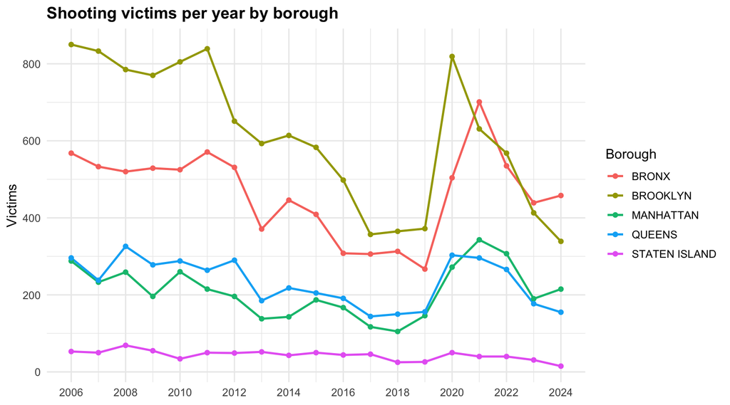

```r
by_year_boro <- nypd %>% count(YEAR, BORO)

ggplot(by_year_boro, aes(YEAR, n, color = BORO)) +
  geom_line(linewidth = 0.9) +
  geom_point(size = 1.6) +
  scale_x_continuous(breaks = seq(2006, 2030, 2)) +
  labs(title    = "Shooting victims per year by borough",
       x = NULL, y = "Victims", color = "Borough") +
  theme_minimal(base_size = 12) +
  theme(plot.title = element_text(face = "bold"))
```

```r
totals <- nypd %>% count(YEAR, name = "victims")

peak_year   <- totals %>% slice_max(victims, n = 1)
trough_year <- totals %>% filter(YEAR < 2020) %>% slice_min(victims, n = 1)
spike_2020  <- totals %>% filter(YEAR %in% c(2019, 2020))

totals %>% print(n = Inf)
```

```
## # A tibble: 19 × 2
##     YEAR victims
##    <dbl>   <int>
##  1  2006    2055
##  2  2007    1887
##  3  2008    1959
##  4  2009    1828
##  5  2010    1912
##  6  2011    1939
##  7  2012    1717
##  8  2013    1339
##  9  2014    1464
## 10  2015    1434
## 11  2016    1208
## 12  2017     970
## 13  2018     958
## 14  2019     967
## 15  2020    1948
## 16  2021    2011
## 17  2022    1716
## 18  2023    1250
## 19  2024    1182
```

Shooting volume fell steadily through the 2010s and hit a low of 958 victims in 2018, then rose radpidly in 2020 with an increase of 101% in one year. Every borough rose in 2020.

After the peak:

```r
latest_yr <- max(nypd$YEAR)

recovery <- nypd %>%
  filter(YEAR %in% c(2019, latest_yr)) %>%
  mutate(period = if_else(YEAR == 2019, "pre", "latest")) %>%
  count(BORO, period) %>%
  pivot_wider(names_from = period, values_from = n) %>%
  mutate(change_vs_2019 = percent(latest / pre - 1, accuracy = 1)) %>%
  arrange(desc(latest / pre))
recovery
```

```
## # A tibble: 5 × 4
##   BORO          latest   pre change_vs_2019
##   <fct>          <int> <int> <chr>
## 1 BRONX            458   267 72%
## 2 MANHATTAN        215   146 47%
## 3 QUEENS           155   156 -1%
## 4 BROOKLYN         339   372 -9%
## 5 STATEN ISLAND     15    26 -42%
```

```r
# years in which the Bronx recorded more victims than Brooklyn
nypd %>%
  filter(BORO %in% c("BRONX", "BROOKLYN")) %>%
  count(YEAR, BORO) %>%
  pivot_wider(names_from = BORO, values_from = n) %>%
  filter(BRONX > BROOKLYN)
```

```
## # A tibble: 3 × 3
##    YEAR BRONX BROOKLYN
##   <dbl> <int>    <int>
## 1  2021   701      631
## 2  2023   439      413
## 3  2024   458      339
```

By 2024, some boroughs were back at or below their 2019 level. The Bronx recorded more shooting victims than Brooklyn in several recent years even with its less dense population.

## Finding 2: Volume and fatality run in opposite directions across the day

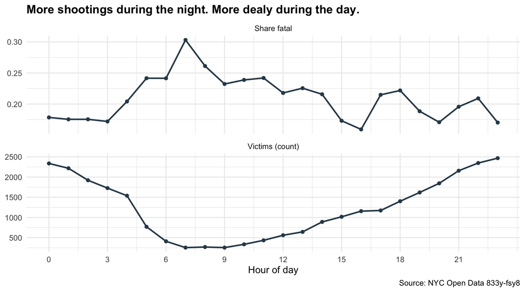

```r
by_hour <- nypd %>%
  group_by(OCCUR_HOUR) %>%
  summarise(victims = n(),
            deaths  = sum(STATISTICAL_MURDER_FLAG),
            rate    = deaths / victims)

by_hour %>%
  select(OCCUR_HOUR, victims, rate) %>%
  pivot_longer(c(victims, rate)) %>%
  mutate(name = recode(name,
                       victims = "Victims (count)",
                       rate    = "Share fatal")) %>%
  ggplot(aes(OCCUR_HOUR, value)) +
  geom_line(linewidth = 0.9, color = "#2F4858") +
  geom_point(size = 1.6, color = "#2F4858") +
  facet_wrap(~name, scales = "free_y", ncol = 1) +
  scale_x_continuous(breaks = seq(0, 23, 3)) +
  labs(title    = "More shootings during the night. More dealy during the day.",
       x = "Hour of day", y = NULL,
       caption  = "Source: NYC Open Data 833y-fsy8") +
  theme_minimal(base_size = 12) +
  theme(plot.title = element_text(face = "bold"))
```

```r
by_hour %>% mutate(rate = percent(rate, accuracy = 0.1)) %>% print(n = Inf)
```

```
## # A tibble: 24 × 4
##    OCCUR_HOUR victims deaths rate
##         <int>   <int>  <int> <chr>
##  1          0    2337    417 17.8%
##  2          1    2218    389 17.5%
##  3          2    1921    337 17.5%
##  4          3    1727    297 17.2%
##  5          4    1538    314 20.4%
##  6          5     770    186 24.2%
##  7          6     410     99 24.1%
##  8          7     254     77 30.3%
##  9          8     268     70 26.1%
## 10          9     254     59 23.2%
## 11         10     335     80 23.9%
## 12         11     434    105 24.2%
## 13         12     560    122 21.8%
## 14         13     643    145 22.6%
## 15         14     890    192 21.6%
## 16         15    1017    176 17.3%
## 17         16    1156    184 15.9%
## 18         17    1173    252 21.5%
## 19         18    1402    311 22.2%
## 20         19    1619    305 18.8%
## 21         20    1845    315 17.1%
## 22         21    2157    422 19.6%
## 23         22    2348    491 20.9%
## 24         23    2468    420 17.0%
```

```r
hour_cor <- cor.test(by_hour$victims, by_hour$rate)
hour_cor
```

```
##
##  Pearson's product-moment correlation
##
## data:  by_hour$victims and by_hour$rate
## t = -5.3675, df = 22, p-value = 2.174e-05
## alternative hypothesis: true correlation is not equal to 0
## 95 percent confidence interval:
##  -0.8869730 -0.5021318
## sample estimates:
##        cor
## -0.7530018
```

```r
band_levels <- c("Late night (00-04)", "Morning (05-11)",
                 "Afternoon (12-17)", "Evening (18-23)")

nypd <- nypd %>%
  mutate(TIME_BAND = factor(case_when(
    OCCUR_HOUR <= 4  ~ band_levels[1],
    OCCUR_HOUR <= 11 ~ band_levels[2],
    OCCUR_HOUR <= 17 ~ band_levels[3],
    TRUE             ~ band_levels[4]), levels = band_levels))

by_band <- nypd %>%
  group_by(TIME_BAND) %>%
  summarise(victims = n(),
            deaths  = sum(STATISTICAL_MURDER_FLAG),
            rate    = deaths / victims)
by_band %>% mutate(rate = percent(rate, accuracy = 0.1))
```

```
## # A tibble: 4 × 4
##   TIME_BAND          victims deaths rate
##   <fct>                <int>  <int> <chr>
## 1 Late night (00-04)    9741   1754 18.0%
## 2 Morning (05-11)       2725    676 24.8%
## 3 Afternoon (12-17)     5439   1071 19.7%
## 4 Evening (18-23)      11839   2264 19.1%
```

```r
morning_rate <- by_band$rate[by_band$TIME_BAND == "Morning (05-11)"]
rest_rate <- nypd %>%
  filter(TIME_BAND != "Morning (05-11)") %>%
  summarise(r = mean(STATISTICAL_MURDER_FLAG)) %>% pull(r)

morning_test <- with(nypd, chisq.test(table(TIME_BAND == "Morning (05-11)",
                                            STATISTICAL_MURDER_FLAG)))
morning_test
```

```
##
##  Pearson's Chi-squared test with Yates' continuity correction
##
## data:  table(TIME_BAND == "Morning (05-11)", STATISTICAL_MURDER_FLAG)
## X-squared = 56.126, df = 1, p-value = 6.796e-14
```

Volume peaks late at night: the busiest hour has 9.7 times as many victims as the quietest. The fatality rate runs the opposite way. The correlation between hourly volume and hourly fatality rate is -0.75 (p = 2.2^{-5}).

Aggregating 05:00 to 11:59, morning shootings are fatal 24.8% of the time, against 18.8% for the rest of the day, a ratio of 1.32

# Step 4: Bias and Conclusion

```r
nypd %>%
  count(BORO, sort = TRUE) %>%
  mutate(share = percent(n / sum(n), accuracy = 0.1))
```

```
## # A tibble: 5 × 3
##   BORO              n share
##   <fct>         <int> <chr>
## 1 BROOKLYN      11685 39.3%
## 2 BRONX          8834 29.7%
## 3 QUEENS         4426 14.9%
## 4 MANHATTAN      3977 13.4%
## 5 STATEN ISLAND   822 2.8%
```

Joining NYC population estimates would convert these to per-capita rates and could reorder the boroughs substantially. That join is the obvious next step and is deliberately left as an open question rather than papered over.

**The outcome variable is not purely about violence.** Whether a victim dies depends in part on how quickly they reach ER. `STATISTICAL_MURDER_FLAG` therefore blends the severity of the shooting with the quality and proximity of emergency medical care — a confound sitting inside the dependent variable itself.

**This is police-recorded data.** It captures shootings the NYPD recorded. Anything not reported to or recorded by the police is absent by construction, and reporting propensity is unlikely to be uniform across neighbourhoods.

## Conclusion

New York’s shooting volume fell by more than half over the 2010s and then roughly doubled in 2020. Every borough rose together, but they did not come down together: by 2024 some had returned to their 2019 levels while the Bronx and Manhattan remained well above them.